# Ventas Apple Trimestrales Series Temporales

Mario Arteche Miranda

2020-11-16

[figure not shown]

## Cargamos las librerias y los datos:

```r
require(forecast)
require(xts)
require(ggplot2)
library(ggplot2)
library(tidyr)
library(skimr)
library(zoo)
require(forecast)
library(forecast)
require(xts)
library(xts)
library(lubridate) #manipular fechas
library(magrittr)
library(ggfortify)
library(tidyverse)
library(stringr)
library(dplyr)
library(aTSA)
library(autoplotly)
library(urca)
library(dplyr)
library(knitr)
```

## Cargamos nuestro dataset:

Nuestro dataset no muestra ni valores nulos ni repetidos, lo que nos permite continuar con el análisis.

```r
df <- read.csv("Apple.csv", sep = ";")
skim(df)
```

Data summary

| Name | df |
| --- | --- |
| Number of rows | 38 |
| Number of columns | 2 |
| _______________________ |  |
| Column type frequency: |  |
| character | 1 |
| numeric | 1 |
| ________________________ |  |
| Group variables | None |

**Variable type: character**

| skim_variable | n_missing | complete_rate | min | max | empty | n_unique | whitespace |
| --- | --- | --- | --- | --- | --- | --- | --- |
| Trimestre | 0 | 1 | 7 | 7 | 0 | 38 | 0 |

**Variable type: numeric**

| skim_variable | n_missing | complete_rate | mean | sd | p0 | p25 | p50 | p75 | p100 | hist |
| --- | --- | --- | --- | --- | --- | --- | --- | --- | --- | --- |
| Ingresos | 0 | 1 | 36292.47 | 19632.6 | 7561 | 16860.75 | 37452 | 48916.75 | 78351 | ▇▃▇▃▂ |

```r
names(df)
```

```
## [1] "Trimestre" "Ingresos"
```

## Creamos un objeto con las fechas de formato trimestral:

```r
fechas <- seq(as.Date("2008-04-01"), as.Date("2017-09-30"), by = "quarter")
fechas
```

```
##  [1] "2008-04-01" "2008-07-01" "2008-10-01" "2009-01-01" "2009-04-01"
##  [6] "2009-07-01" "2009-10-01" "2010-01-01" "2010-04-01" "2010-07-01"
## [11] "2010-10-01" "2011-01-01" "2011-04-01" "2011-07-01" "2011-10-01"
## [16] "2012-01-01" "2012-04-01" "2012-07-01" "2012-10-01" "2013-01-01"
## [21] "2013-04-01" "2013-07-01" "2013-10-01" "2014-01-01" "2014-04-01"
## [26] "2014-07-01" "2014-10-01" "2015-01-01" "2015-04-01" "2015-07-01"
## [31] "2015-10-01" "2016-01-01" "2016-04-01" "2016-07-01" "2016-10-01"
## [36] "2017-01-01" "2017-04-01" "2017-07-01"
```

```r
df <- mutate(df, fecha = fechas)
str(df)
```

```
## 'data.frame':    38 obs. of  3 variables:
##  $ Trimestre: chr  "Q2 2008" "Q3 2008" "Q4 2008" "Q1 2009" ...
##  $ Ingresos : int  7980 7561 11520 11880 9084 9734 12207 15683 13499 15700 ...
##  $ fecha    : Date, format: "2008-04-01" "2008-07-01" ...
```

## Pasamos a formato temporal –> xts(series temporales):

```r
Ventas = xts(df$Ingresos, order.by = as.Date(df$fecha,"%Y/%m/%d"),frequency = 4)
Ventas = to.quarterly(Ventas)
```

## Ponemos en formato zoo y hacemos un gráfico de las ventas:

En el cual vemos que las ventas no siguen ningun patrón estacionario ni en media ni en varianza.

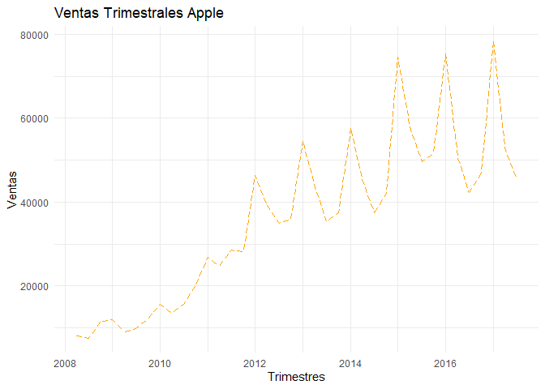

```r
zVentas = as.zoo(Ventas$Ventas.Close)
autoplot(as.xts(zVentas),
         ts.colour = 'orange',
         ts.linetype = 'longdash') +
  ggtitle("Ventas Trimestrales Apple") +
  xlab("Trimestres") +
  ylab("Ventas") +
  theme_minimal()
```

## Representamos las ventas de manera trimestral con el fin de buscar “patrones” en los datos:

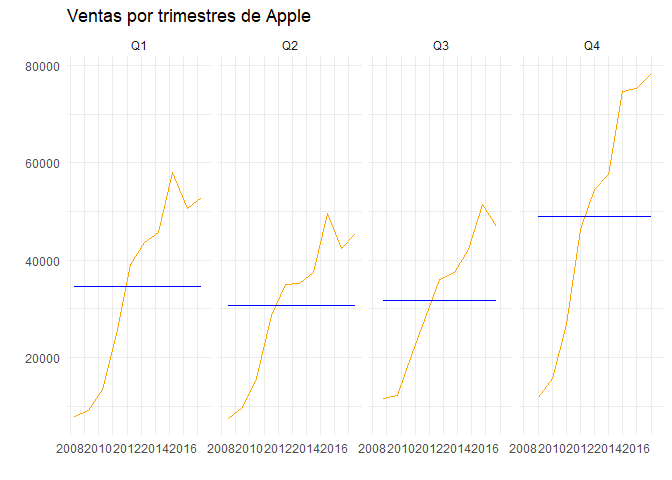

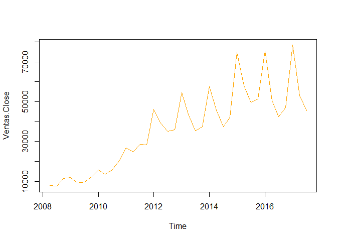

```
##  Call:
##  stl(x = tsVentas[, 1], s.window = "periodic")
##
## Components
##          seasonal     trend   remainder
## 2008 Q2 -1191.515 11987.713 -2816.19786
## 2008 Q3 -6202.795 11054.647  2709.14756
## 2008 Q4 -4388.396 10306.954  5601.44193
## 2009 Q1 11782.720  9712.795 -9615.51515
## 2009 Q2 -1191.515 10313.378   -37.86329
## 2009 Q3 -6202.795 11865.051  4071.74373
## 2009 Q4 -4388.396 12348.763  4246.63276
## 2010 Q1 11782.720 12927.130 -9026.85026
## 2010 Q2 -1191.515 14968.422  -277.90712
## 2010 Q3 -6202.795 18282.820  3619.97453
```

[output cut: 28 more lines]

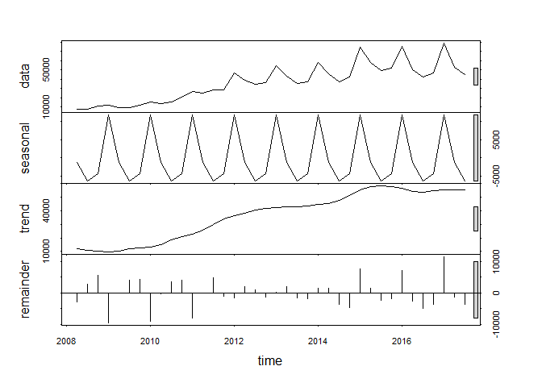

## Creamos la muestra, dejando fuera los datos de 2017:

## Modelo ETS:

Predecir series temporales, las cuales presenten dos posibles componentes uno estacional y otro tendencial.

```
## [1] "ETS(M,A,M)"
```

```
##
## Forecast method: ETS(M,A,M)
##
## Model Information:
## ETS(M,A,M)
##
## Call:
##  ets(y = oVentas)
##
##   Smoothing parameters:
##     alpha = 0.493
##     beta  = 0.493
##     gamma = 0.507
##
##   Initial states:
##     l = 7125.3462
##     b = 1485.7975
##     s = 1.1511 1.1163 0.8322 0.9004
##
##   sigma:  0.1222
##
##      AIC     AICc      BIC
## 703.9538 711.1538 717.9519
##
## Error measures:
##                   ME     RMSE      MAE       MPE     MAPE      MASE      ACF1
## Training set -41.934 4120.155 2883.262 -0.297759 8.677434 0.4160202 0.1438481
##
## Forecasts:
##         Point Forecast     Lo 80     Hi 80      Lo 95     Hi 95
## 2017 Q1       69439.83 58568.387  80311.27  52813.394  86066.26
## 2017 Q2       53347.98 41773.016  64922.95  35645.598  71050.37
## 2017 Q3       48972.04 33884.613  64059.47  25897.811  72046.27
## 2017 Q4       54176.09 31475.035  76877.14  19457.824  88894.35
## 2018 Q1       80540.07 32680.293 128399.85   7344.857 153735.28
## 2018 Q2       61619.03 17211.212 106026.85  -6296.866 129534.93
## 2018 Q3       56344.41  7869.773 104819.05 -17791.151 130479.97
## 2018 Q4       62103.80  -718.363 124925.97 -33974.410 158182.02
```

|  | Point Forecast | Lo 80 | Hi 80 | Lo 95 | Hi 95 |
| --- | --- | --- | --- | --- | --- |
| 2017 Q1 | 69439.83 | 58568.387 | 80311.27 | 52813.394 | 86066.26 |
| 2017 Q2 | 53347.98 | 41773.016 | 64922.95 | 35645.598 | 71050.37 |
| 2017 Q3 | 48972.04 | 33884.613 | 64059.47 | 25897.811 | 72046.27 |
| 2017 Q4 | 54176.09 | 31475.035 | 76877.14 | 19457.824 | 88894.35 |
| 2018 Q1 | 80540.07 | 32680.293 | 128399.85 | 7344.857 | 153735.28 |
| 2018 Q2 | 61619.03 | 17211.212 | 106026.85 | -6296.866 | 129534.93 |
| 2018 Q3 | 56344.41 | 7869.773 | 104819.05 | -17791.151 | 130479.97 |
| 2018 Q4 | 62103.80 | -718.363 | 124925.97 | -33974.410 | 158182.02 |

## Graficamos los errores:

El ruido blanco es el error ideal (media 0, varianza cte.). Para que el modelo sea correcto, el error de series temporales ha de ser de tipo ruido blanco. No hay modelo que explique el ruido blanco. El ruido blanco no tiene autocorrelación de ningún tipo.

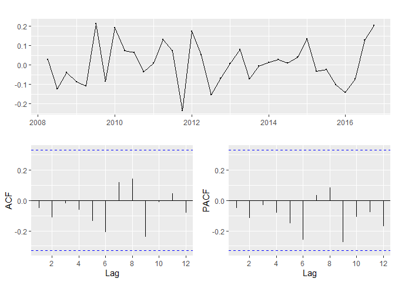

## Graficamos la predicción:

La linea naranja es el valor real, la linea azul la predicción, y el area gris es el intervalo de confianza.

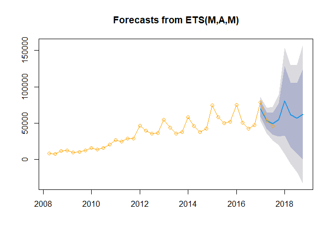

## Modelo ARIMA:

```
## Series: oVentas
## ARIMA(0,1,0)(0,1,0)[4]
## Box Cox transformation: lambda= 0
##
## sigma^2 estimated as 0.01472:  log likelihood=20.72
## AIC=-39.45   AICc=-39.3   BIC=-38.04
##
## Training set error measures:
##                     ME     RMSE      MAE       MPE     MAPE      MASE      ACF1
## Training set -764.5058 4786.405 3054.054 -1.321616 8.284962 0.4406634 0.1269135
```

## Graficamos los residuos:

El ruido blanco es el error ideal (media 0, varianza cte.). Para que el modelo sea correcto, el error de series temporales ha de ser de tipo ruido blanco. No hay modelo que explique el ruido blanco. El ruido blanco no tiene autocorrelación de ningún tipo.

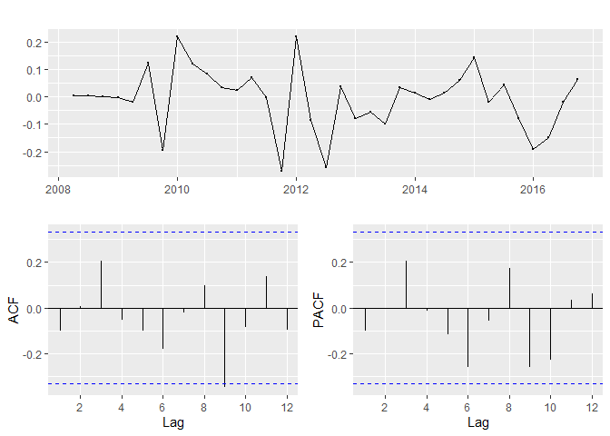

## Creamos un dataset:

## Hacemos la predicción y graficamos:

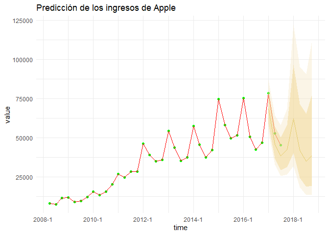

## Resumen de las predicciones:

```
##
## Forecast method: ARIMA(0,1,0)(0,1,0)[4]
##
## Model Information:
## Series: oVentas
## ARIMA(0,1,0)(0,1,0)[4]
## Box Cox transformation: lambda= 0
##
## sigma^2 estimated as 0.01472:  log likelihood=20.72
## AIC=-39.45   AICc=-39.3   BIC=-38.04
##
## Error measures:
##                     ME     RMSE      MAE       MPE     MAPE      MASE      ACF1
## Training set -764.5058 4786.405 3054.054 -1.321616 8.284962 0.4406634 0.1269135
##
## Forecasts:
##         Point Forecast    Lo 80    Hi 80    Lo 95     Hi 95
## 2017 Q1       68524.50 58656.57 80052.53 54021.77  86920.63
## 2017 Q2       45993.21 36914.17 57305.26 32857.77  64379.78
## 2017 Q3       38534.34 29436.35 50444.28 25525.07  58174.00
## 2017 Q4       42622.67 31230.74 58169.99 26490.28  68579.55
## 2018 Q1       62338.78 40156.60 96774.23 31816.09 122143.34
## 2018 Q2       41841.40 24416.21 71702.49 18358.80  95360.44
## 2018 Q3       35055.84 18821.04 65294.59 13541.05  90754.54
## 2018 Q4       38775.11 19344.31 77723.59 13387.03 112310.89
```

|  | Point Forecast | Lo 80 | Hi 80 | Lo 95 | Hi 95 |
| --- | --- | --- | --- | --- | --- |
| 2017 Q1 | 68524.50 | 58656.57 | 80052.53 | 54021.77 | 86920.63 |
| 2017 Q2 | 45993.21 | 36914.17 | 57305.26 | 32857.77 | 64379.78 |
| 2017 Q3 | 38534.34 | 29436.35 | 50444.28 | 25525.07 | 58174.00 |
| 2017 Q4 | 42622.67 | 31230.74 | 58169.99 | 26490.28 | 68579.55 |
| 2018 Q1 | 62338.78 | 40156.60 | 96774.23 | 31816.09 | 122143.34 |
| 2018 Q2 | 41841.40 | 24416.21 | 71702.49 | 18358.80 | 95360.44 |
| 2018 Q3 | 35055.84 | 18821.04 | 65294.59 | 13541.05 | 90754.54 |
| 2018 Q4 | 38775.11 | 19344.31 | 77723.59 | 13387.03 | 112310.89 |

## Concluisiones:

[figure not shown]